# Assignment

Ivy Li

03/01/2020

## Background

Using devices such as Jawbone Up, Nike FuelBand, and Fitbit it is now possible to collect a large amount of data about personal activity relatively inexpensively. These type of devices are part of the quantified self movement – a group of enthusiasts who take measurements about themselves regularly to improve their health, to find patterns in their behavior, or because they are tech geeks. One thing that people regularly do is quantify how much of a particular activity they do, but they rarely quantify how well they do it. In this project, your goal will be to use data from accelerometers on the belt, forearm, arm, and dumbell of 6 participants. They were asked to perform barbell lifts correctly and incorrectly in 5 different ways. More information is available from the website here: http://web.archive.org/web/20161224072740/http:/groupware.les.inf.puc-rio.br/har (see the section on the Weight Lifting Exercise Dataset).

## Objective

The goal of your project is to predict the manner in which they did the exercise. This is the “classe” variable in the training set. You may use any of the other variables to predict with. 1. You should create a report describing how you built your model 2. how you used cross validation 3. what you think the expected out of sample error is 4. why you made the choices you did 5. You will also use your prediction model to predict 20 different test cases

## Data

The training data for this project are available here:

https://d396qusza40orc.cloudfront.net/predmachlearn/pml-training.csv

The test data are available here:

https://d396qusza40orc.cloudfront.net/predmachlearn/pml-testing.csv

## Install Packages

```r
library(ggplot2)
library(cowplot)
library(caret)
```

## Load the data

```r
train.data <- read.csv("C:/Users/IvyLi/Documents/R Codes/pml-training.csv")
test.data <- read.csv("C:/Users/IvyLi/Documents/R Codes/pml-testing.csv")

# remove those variables without any values
train <- train.data[,colSums(is.na(train.data)) == 0]
train <- train[c(2:93)]

test <- test.data[,colSums(is.na(test.data)) == 0]
test <- test[c(2:60)]

header <- c("user_name",names(test)[7:58], "classe")

train2 <- subset(train, select = header)
```

## Summarise Dataset

```r
dim(train2)
```

```
## [1] 19622    54
```

```r
head(train2)
```

```
##   user_name roll_belt pitch_belt yaw_belt total_accel_belt gyros_belt_x
## 1  carlitos      1.41       8.07    -94.4                3         0.00
## 2  carlitos      1.41       8.07    -94.4                3         0.02
## 3  carlitos      1.42       8.07    -94.4                3         0.00
## 4  carlitos      1.48       8.05    -94.4                3         0.02
## 5  carlitos      1.48       8.07    -94.4                3         0.02
## 6  carlitos      1.45       8.06    -94.4                3         0.02
##   gyros_belt_y gyros_belt_z accel_belt_x accel_belt_y accel_belt_z
## 1         0.00        -0.02          -21            4           22
## 2         0.00        -0.02          -22            4           22
## 3         0.00        -0.02          -20            5           23
## 4         0.00        -0.03          -22            3           21
## 5         0.02        -0.02          -21            2           24
## 6         0.00        -0.02          -21            4           21
##   magnet_belt_x magnet_belt_y magnet_belt_z roll_arm pitch_arm yaw_arm
```

[output cut: 62 more lines]

```r
summary(train2)
```

```
##     user_name      roll_belt        pitch_belt          yaw_belt
##  adelmo  :3892   Min.   :-28.90   Min.   :-55.8000   Min.   :-180.00
##  carlitos:3112   1st Qu.:  1.10   1st Qu.:  1.7600   1st Qu.: -88.30
##  charles :3536   Median :113.00   Median :  5.2800   Median : -13.00
##  eurico  :3070   Mean   : 64.41   Mean   :  0.3053   Mean   : -11.21
##  jeremy  :3402   3rd Qu.:123.00   3rd Qu.: 14.9000   3rd Qu.:  12.90
##  pedro   :2610   Max.   :162.00   Max.   : 60.3000   Max.   : 179.00
##  total_accel_belt  gyros_belt_x        gyros_belt_y       gyros_belt_z
##  Min.   : 0.00    Min.   :-1.040000   Min.   :-0.64000   Min.   :-1.4600
##  1st Qu.: 3.00    1st Qu.:-0.030000   1st Qu.: 0.00000   1st Qu.:-0.2000
##  Median :17.00    Median : 0.030000   Median : 0.02000   Median :-0.1000
##  Mean   :11.31    Mean   :-0.005592   Mean   : 0.03959   Mean   :-0.1305
##  3rd Qu.:18.00    3rd Qu.: 0.110000   3rd Qu.: 0.11000   3rd Qu.:-0.0200
##  Max.   :29.00    Max.   : 2.220000   Max.   : 0.64000   Max.   : 1.6200
##   accel_belt_x       accel_belt_y     accel_belt_z     magnet_belt_x
##  Min.   :-120.000   Min.   :-69.00   Min.   :-275.00   Min.   :-52.0
##  1st Qu.: -21.000   1st Qu.:  3.00   1st Qu.:-162.00   1st Qu.:  9.0
##  Median : -15.000   Median : 35.00   Median :-152.00   Median : 35.0
##  Mean   :  -5.595   Mean   : 30.15   Mean   : -72.59   Mean   : 55.6
##  3rd Qu.:  -5.000   3rd Qu.: 61.00   3rd Qu.:  27.00   3rd Qu.: 59.0
##  Max.   :  85.000   Max.   :164.00   Max.   : 105.00   Max.   :485.0
##  magnet_belt_y   magnet_belt_z       roll_arm         pitch_arm
##  Min.   :354.0   Min.   :-623.0   Min.   :-180.00   Min.   :-88.800
##  1st Qu.:581.0   1st Qu.:-375.0   1st Qu.: -31.77   1st Qu.:-25.900
##  Median :601.0   Median :-320.0   Median :   0.00   Median :  0.000
##  Mean   :593.7   Mean   :-345.5   Mean   :  17.83   Mean   : -4.612
##  3rd Qu.:610.0   3rd Qu.:-306.0   3rd Qu.:  77.30   3rd Qu.: 11.200
##  Max.   :673.0   Max.   : 293.0   Max.   : 180.00   Max.   : 88.500
##     yaw_arm          total_accel_arm  gyros_arm_x        gyros_arm_y
##  Min.   :-180.0000   Min.   : 1.00   Min.   :-6.37000   Min.   :-3.4400
##  1st Qu.: -43.1000   1st Qu.:17.00   1st Qu.:-1.33000   1st Qu.:-0.8000
##  Median :   0.0000   Median :27.00   Median : 0.08000   Median :-0.2400
##  Mean   :  -0.6188   Mean   :25.51   Mean   : 0.04277   Mean   :-0.2571
##  3rd Qu.:  45.8750   3rd Qu.:33.00   3rd Qu.: 1.57000   3rd Qu.: 0.1400
##  Max.   : 180.0000   Max.   :66.00   Max.   : 4.87000   Max.   : 2.8400
##   gyros_arm_z       accel_arm_x       accel_arm_y      accel_arm_z
##  Min.   :-2.3300   Min.   :-404.00   Min.   :-318.0   Min.   :-636.00
##  1st Qu.:-0.0700   1st Qu.:-242.00   1st Qu.: -54.0   1st Qu.:-143.00
##  Median : 0.2300   Median : -44.00   Median :  14.0   Median : -47.00
##  Mean   : 0.2695   Mean   : -60.24   Mean   :  32.6   Mean   : -71.25
```

[output cut: 43 more lines]

```
##  Max.   :  3.970   Max.   :311.00000   Max.   :231.0000   Max.   : 477.00
##  accel_forearm_y  accel_forearm_z   magnet_forearm_x  magnet_forearm_y
##  Min.   :-632.0   Min.   :-446.00   Min.   :-1280.0   Min.   :-896.0
##  1st Qu.:  57.0   1st Qu.:-182.00   1st Qu.: -616.0   1st Qu.:   2.0
##  Median : 201.0   Median : -39.00   Median : -378.0   Median : 591.0
##  Mean   : 163.7   Mean   : -55.29   Mean   : -312.6   Mean   : 380.1
##  3rd Qu.: 312.0   3rd Qu.:  26.00   3rd Qu.:  -73.0   3rd Qu.: 737.0
##  Max.   : 923.0   Max.   : 291.00   Max.   :  672.0   Max.   :1480.0
##  magnet_forearm_z classe
##  Min.   :-973.0   A:5580
##  1st Qu.: 191.0   B:3797
##  Median : 511.0   C:3422
##  Mean   : 393.6   D:3216
##  3rd Qu.: 653.0   E:3607
##  Max.   :1090.0
```

## K-fold Cross Validation

K-fold cross-validation is a robust method for estimating the accuracy of a model.

The k-fold cross-validatioin method evaluates the model performance on different subset of the training data and then calculate the average prediction error rate.

The algorithm is as follow:

1. Randomly split the data set into k-subsets
2. Reserve one subset and train the model on all other subsets
3. Test the model on the reserved subset and record the prediction error
4. Repeat this process until each of the k subsets has served as the test set
5. Compute the average of the k recorded errors. This is called the cross-validation error serving as the performance metric for the model.

In this scenario, uses 10-fold cross validation to estimate the prediction error.

The data will then be split into 10 parts, train in 9 and test on 1 and release for all combinations of train-test splits.

A ratio of the number of correctly predicted instances in divided by the total number of instances in the dataset multiplied by 100 to give a percentage.

```r
# Define training control
set.seed(1234)

# Set up a 10-fold cross validation
train.control <- trainControl(method="cv",number = 10)
```

## Build Models

We do not know which algorithms would be good on this problem or what configurations to use. Hence, we evaluate 5 different algorithms:

```r
# Train the model

model.lda <- train(classe ~., data = train2, method = "lda",trControl = train.control, metric = "Accuracy")

model.cart <- train(classe ~., data = train2, method = "rpart",trControl = train.control, metric = "Accuracy")

model.knn <- train(classe ~., data = train2, method = "knn",trControl = train.control, metric = "Accuracy")

model.svm <- train(classe ~., data = train2, method = "svmRadial",trControl = train.control, metric = "Accuracy")

model.rf <- train(classe ~., data = train2, method = "rf",trControl = train.control, metric = "Accuracy")
```

## Select Best Model

Now we need to compare the models to each other and select the most accurate.

```r
# Summarise the results
results <- resamples(list(lda = model.lda, cart = model.cart, knn = model.knn, svm =model.svm,rf = model.rf))

summary(results)
```

```
##
## Call:
## summary.resamples(object = results)
##
## Models: lda, cart, knn, svm, rf
## Number of resamples: 10
##
## Accuracy
##           Min.   1st Qu.    Median      Mean   3rd Qu.      Max. NA's
## lda  0.7212029 0.7287900 0.7322975 0.7328007 0.7359837 0.7533129    0
## cart 0.4880163 0.4980262 0.5070108 0.5089164 0.5184701 0.5343861    0
## knn  0.9209990 0.9275531 0.9294269 0.9301297 0.9320678 0.9408767    0
## svm  0.9164544 0.9343447 0.9352866 0.9363469 0.9443523 0.9449822    0
## rf   0.9923547 0.9949032 0.9956677 0.9953624 0.9964340 0.9969419    0
##
## Kappa
##           Min.   1st Qu.    Median      Mean   3rd Qu.      Max. NA's
## lda  0.6465875 0.6561587 0.6614090 0.6616126 0.6657176 0.6874557    0
## cart 0.3316181 0.3446228 0.3559193 0.3587243 0.3707103 0.3934997    0
## knn  0.8999874 0.9083287 0.9106965 0.9115962 0.9140652 0.9252304    0
## svm  0.8941201 0.9167495 0.9179701 0.9193327 0.9295041 0.9303100    0
## rf   0.9903279 0.9935524 0.9945201 0.9941335 0.9954896 0.9961316    0
```

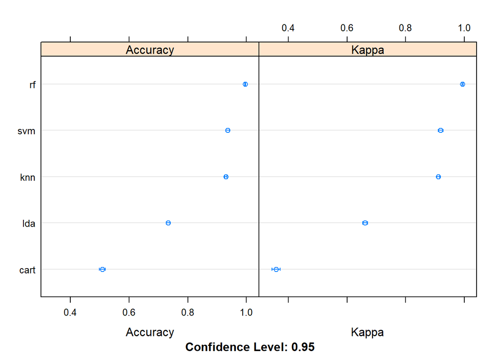

```r
dotplot(results)
```

```r
print(model.rf)
```

```
## Random Forest
##
## 19622 samples
##    53 predictor
##     5 classes: 'A', 'B', 'C', 'D', 'E'
##
## No pre-processing
## Resampling: Cross-Validated (10 fold)
## Summary of sample sizes: 17660, 17660, 17661, 17660, 17659, 17659, ...
## Resampling results across tuning parameters:
##
##   mtry  Accuracy   Kappa
##    2    0.9947507  0.9933596
##   29    0.9953624  0.9941335
##   57    0.9894506  0.9866545
##
## Accuracy was used to select the optimal model using the largest value.
## The final value used for the model was mtry = 29.
```

We can see that the most accurate model in this case was Random Forest.

## Make Prediction

The Random Forest model was the most accurate model. We now can run the Random Forest model directly on the test data and summarise the results in a confusion matrix.

```r
predict_model <- predict(model.rf, test)
confusionMatrix(predict_model,predict(model.rf,test))
```

```
## Confusion Matrix and Statistics
##
##           Reference
## Prediction A B C D E
##          A 7 0 0 0 0
##          B 0 8 0 0 0
##          C 0 0 1 0 0
##          D 0 0 0 1 0
##          E 0 0 0 0 3
##
## Overall Statistics
##
##                Accuracy : 1
##                  95% CI : (0.8316, 1)
##     No Information Rate : 0.4
##     P-Value [Acc > NIR] : 1.1e-08
##
##                   Kappa : 1
##
##  Mcnemar's Test P-Value : NA
##
## Statistics by Class:
##
##                      Class: A Class: B Class: C Class: D Class: E
## Sensitivity              1.00      1.0     1.00     1.00     1.00
## Specificity              1.00      1.0     1.00     1.00     1.00
## Pos Pred Value           1.00      1.0     1.00     1.00     1.00
## Neg Pred Value           1.00      1.0     1.00     1.00     1.00
## Prevalence               0.35      0.4     0.05     0.05     0.15
## Detection Rate           0.35      0.4     0.05     0.05     0.15
## Detection Prevalence     0.35      0.4     0.05     0.05     0.15
## Balanced Accuracy        1.00      1.0     1.00     1.00     1.00
```